# Lipid Analysis

Roshan Shafiha

6/13/2021

## R Markdown

load the libraries

```r
library("readxl")
library("tidyverse")
library("rstatix")
library("DESeq2")
library("EnhancedVolcano")
library("ggplot2")
library("pmp")
library("ggpubr")
library("limma")
```

## Dataset-1

load the files and assign them to respective variable names.

```r
lipid <-as.data.frame(read_excel("italian cohort lipid study.xlsx",sheet = 2))

lipid<-lipid[-1,-277]

clinical_data<-lipid[,1:4]

lipid_data<-lipid[,5:ncol(lipid)]

annotations <- as.data.frame(read_excel("annotations.xlsx",col_names =T))

colnames(lipid_data)<-make.unique(annotations$lipid)

rownames(lipid_data)<-clinical_data$sample_ID

lipid_data<-as.data.frame(lipid_data)

summary(lipid_data[,1:10])
```

```
##     CE_14:0             CE_15:0             CE_16:0            CE_16:0.1
##  Min.   :0.0000000   Min.   :1.885e-05   Min.   :0.0001391   Min.   :0.003984
##  1st Qu.:0.0003600   1st Qu.:8.394e-05   1st Qu.:0.0002549   1st Qu.:0.006530
##  Median :0.0004367   Median :1.192e-04   Median :0.0004512   Median :0.007532
##  Mean   :0.0004403   Mean   :1.187e-04   Mean   :0.0005237   Mean   :0.007500
##  3rd Qu.:0.0005176   3rd Qu.:1.476e-04   3rd Qu.:0.0006468   3rd Qu.:0.008625
##  Max.   :0.0008344   Max.   :2.630e-04   Max.   :0.0016558   Max.   :0.010846
##     CE_16:1            CE_16:1.1           CE_17:0             CE_17:1
##  Min.   :0.000e+00   Min.   :0.001046   Min.   :2.787e-05   Min.   :0.0000000
##  1st Qu.:3.230e-05   1st Qu.:0.002081   1st Qu.:7.312e-05   1st Qu.:0.0001557
##  Median :5.871e-05   Median :0.002471   Median :1.012e-04   Median :0.0002392
##  Mean   :8.938e-05   Mean   :0.002615   Mean   :1.105e-04   Mean   :0.0002002
##  3rd Qu.:1.196e-04   3rd Qu.:0.003015   3rd Qu.:1.453e-04   3rd Qu.:0.0002709
##  Max.   :4.621e-04   Max.   :0.006832   Max.   :2.295e-04   Max.   :0.0003762
##     CE_18:1            CE_18:1.1
##  Min.   :0.0003304   Min.   :0.01170
##  1st Qu.:0.0005593   1st Qu.:0.02253
##  Median :0.0008584   Median :0.02588
##  Mean   :0.0009193   Mean   :0.02585
##  3rd Qu.:0.0011769   3rd Qu.:0.02856
##  Max.   :0.0023625   Max.   :0.04234
```

```r
table(clinical_data$NAFLD)
```

```
##
##   0   1
## 120  21
```

scale the data

```r
lipid_scaled<-scale(lipid_data)

summary(lipid_scaled[,1:10])
```

```
##     CE_14:0            CE_15:0            CE_16:0          CE_16:0.1
##  Min.   :-3.11746   Min.   :-2.21915   Min.   :-1.0770   Min.   :-2.35097
##  1st Qu.:-0.56875   1st Qu.:-0.77224   1st Qu.:-0.7526   1st Qu.:-0.64815
##  Median :-0.02568   Median : 0.01217   Median :-0.2030   Median : 0.02164
##  Mean   : 0.00000   Mean   : 0.00000   Mean   : 0.0000   Mean   : 0.00000
##  3rd Qu.: 0.54740   3rd Qu.: 0.64303   3rd Qu.: 0.3445   3rd Qu.: 0.75223
##  Max.   : 2.79007   Max.   : 3.20715   Max.   : 3.1696   Max.   : 2.23800
##     CE_16:1          CE_16:1.1          CE_17:0           CE_17:1
##  Min.   :-1.0552   Min.   :-1.9408   Min.   :-1.7820   Min.   :-1.8814
##  1st Qu.:-0.6738   1st Qu.:-0.6612   1st Qu.:-0.8060   1st Qu.:-0.4180
##  Median :-0.3621   Median :-0.1781   Median :-0.2014   Median : 0.3673
##  Mean   : 0.0000   Mean   : 0.0000   Mean   : 0.0000   Mean   : 0.0000
##  3rd Qu.: 0.3566   3rd Qu.: 0.4948   3rd Qu.: 0.7513   3rd Qu.: 0.6645
##  Max.   : 4.3995   Max.   : 5.2148   Max.   : 2.5666   Max.   : 1.6547
##     CE_18:1          CE_18:1.1
##  Min.   :-1.3858   Min.   :-2.662815
##  1st Qu.:-0.8471   1st Qu.:-0.625705
##  Median :-0.1432   Median : 0.004171
##  Mean   : 0.0000   Mean   : 0.000000
##  3rd Qu.: 0.6064   3rd Qu.: 0.509735
##  Max.   : 3.3961   Max.   : 3.101539
```

conduct PCA analysis

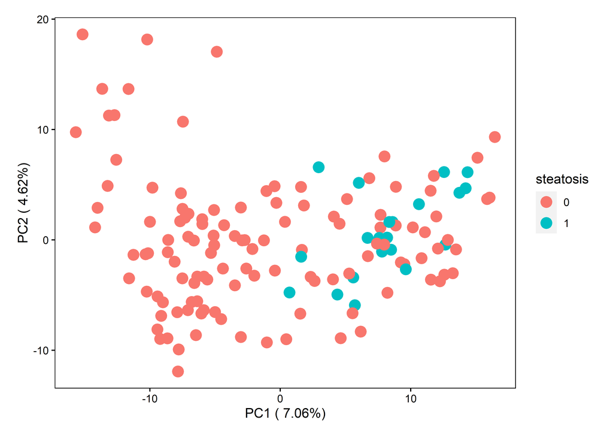

```r
res_pca_1<-prcomp(lipid_scaled,centre=T,scale=F)

res_pca <- as.data.frame(res_pca_1$x)

res_pca$steatosis<-clinical_data$NAFLD

res_pca$sample<-clinical_data$sample_ID


theme<-theme(panel.background = element_blank(),panel.border=element_rect(fill=NA),panel.grid.major = element_blank(),panel.grid.minor = element_blank(),strip.background=element_blank(),axis.text.x=element_text(colour="black"),axis.text.y=element_text(colour="black"),axis.ticks=element_line(colour="black"),plot.margin=unit(c(1,1,1,1),"line"))


percentage <- round(res_pca_1$sdev / sum(res_pca_1$sdev) * 100, 2)
percentage <- paste( colnames(res_pca), "(", paste( as.character(percentage), "%", ")", sep="") )


plot1<-ggplot(res_pca,aes(x=PC1,y=PC2,label= sample,color=steatosis ))

plot1<-plot1+geom_point(size=4)+theme+ xlab(percentage[1]) + ylab(percentage[2])

print(plot1)
```

rename the sample in clinical data

```r
clinical_data$NAFLD[clinical_data$NAFLD==0]<-"steatosis0"

clinical_data$NAFLD[clinical_data$NAFLD==1]<-"steatosis1"

head(clinical_data)
```

```
##   sample_ID patient_no      NAFLD sex
## 2        N1          1 steatosis0   F
## 3        N2          1 steatosis0   F
## 4        N3          1 steatosis0   F
## 5        N4          1 steatosis0   F
## 6        N5          1 steatosis0   F
## 7        N6          1 steatosis0   F
```

Extract the steatosis 0 and steatosis 1 sample separately

```r
clinical_data_steatosis0<-subset(clinical_data, NAFLD=="steatosis0",select=sample_ID:sex)

clinical_data_steatosis1<-subset(clinical_data, NAFLD=="steatosis1",select=sample_ID:sex)

head(clinical_data_steatosis1)
```

```
##    sample_ID patient_no      NAFLD sex
## 76       N75         15 steatosis1   F
## 77       N76         15 steatosis1   F
## 82       N81         18 steatosis1   F
## 83       N82         18 steatosis1   F
## 86       N85         20 steatosis1   M
## 87       N86         20 steatosis1   M
```

```r
head(clinical_data_steatosis0)
```

```
##   sample_ID patient_no      NAFLD sex
## 2        N1          1 steatosis0   F
## 3        N2          1 steatosis0   F
## 4        N3          1 steatosis0   F
## 5        N4          1 steatosis0   F
## 6        N5          1 steatosis0   F
## 7        N6          1 steatosis0   F
```

lets see how many steatosis0 and steatosis1 samples are present

```r
nrow(clinical_data_steatosis0)
```

```
## [1] 120
```

```r
nrow(clinical_data_steatosis1)
```

```
## [1] 21
```

There are more steatosis0 than steatosis 1 , hence lets conduct differential expression of lipid analysis between these two groups by subseting the samples into separate batches.

create 6 batches of distinct (without sample replacement of steatosis0) and conduct differential expression of lipid for each batch of steatosis0 and steatosis1 such as (20 vs 21) and identify the repeatedly arising significant gene between them.

Lets create 6 batches

```r
rownames(clinical_data_steatosis0)<-1:120

batch1_clinical_data_steatosis0<-clinical_data_steatosis0[1:20,]

batch2_clinical_data_steatosis0<-clinical_data_steatosis0[21:40,]

batch3_clinical_data_steatosis0<-clinical_data_steatosis0[41:60,]

batch4_clinical_data_steatosis0<-clinical_data_steatosis0[61:80,]

batch5_clinical_data_steatosis0<-clinical_data_steatosis0[81:100,]

batch6_clinical_data_steatosis0<-clinical_data_steatosis0[101:120,]
```

now create the clinical data for those 6 batches by merging clinical batch of steatosis0 and steatosis1

```r
batch1_clinical_data<-rbind(batch1_clinical_data_steatosis0,clinical_data_steatosis1)

batch2_clinical_data<-rbind(batch2_clinical_data_steatosis0,clinical_data_steatosis1)

batch3_clinical_data<-rbind(batch3_clinical_data_steatosis0,clinical_data_steatosis1)

batch4_clinical_data<-rbind(batch4_clinical_data_steatosis0,clinical_data_steatosis1)

batch5_clinical_data<-rbind(batch5_clinical_data_steatosis0,clinical_data_steatosis1)

batch6_clinical_data<-rbind(batch6_clinical_data_steatosis0,clinical_data_steatosis1)
```

extract the expression data for each of the batches now

```r
batch1_lipid_scaled<-lipid_scaled[rownames(lipid_scaled) %in% batch1_clinical_data$sample_ID,]

batch2_lipid_scaled<-lipid_scaled[rownames(lipid_scaled) %in% batch2_clinical_data$sample_ID,]

batch3_lipid_scaled<-lipid_scaled[rownames(lipid_scaled) %in% batch3_clinical_data$sample_ID,]

batch4_lipid_scaled<-lipid_scaled[rownames(lipid_scaled) %in% batch4_clinical_data$sample_ID,]

batch5_lipid_scaled<-lipid_scaled[rownames(lipid_scaled) %in% batch5_clinical_data$sample_ID,]

batch6_lipid_scaled<-lipid_scaled[rownames(lipid_scaled) %in% batch6_clinical_data$sample_ID,]
```

## Differential lipid analysis

conduct differential lipid expression analysis for batch-1

```r
design_batch1 <- model.matrix(~0+batch1_clinical_data$NAFLD,ref="steatosis0")

colnames(design_batch1) <- c("Steatosis0","Steatosis1")

lipid_data_limma1<-t(batch1_lipid_scaled)

fit_data1 <- lmFit(lipid_data_limma1, design_batch1)

contrasts1 <- makeContrasts(Steatosis1 - Steatosis0, levels=design_batch1)

fit2_data1 <- contrasts.fit(fit_data1, contrasts1)

fit2_data1<- eBayes(fit2_data1)

full_results1 <- topTable(fit2_data1, number=Inf,adjust = "BH")

full_results1 <- cbind(symbols = rownames(full_results1), full_results1)

rownames(full_results1) <- 1:nrow(full_results1)
```

lets view the plot for batch 1 and extract the significant genes of them

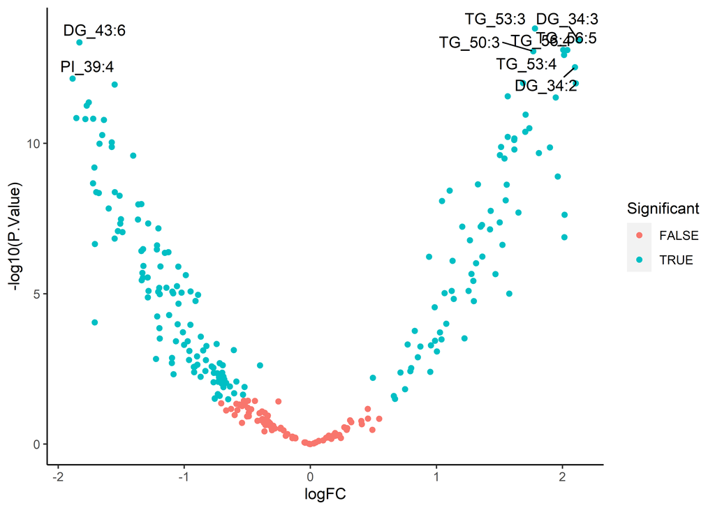

```r
p_cutoff <- 0.05
fc_cutoff <- 1
topN <-10

full_results1 %>%
  mutate(Significant = adj.P.Val < p_cutoff, abs(logFC) > fc_cutoff ) %>%
  mutate(Rank = 1:n(), Label = ifelse(Rank < topN,symbols,"")) %>%
  ggplot(aes(x = logFC, y = -log10(P.Value), col=Significant,label=Label)) + geom_point() + geom_text_repel(col="black")+ theme(panel.grid.major = element_blank(), panel.grid.minor = element_blank(),panel.background = element_blank(), axis.line = element_line(colour = "black"))
```

```r
significant_batch1<-full_results1[full_results1$adj.P.Val<p_cutoff,]

head(significant_batch1)
```

```
##   symbols     logFC      AveExpr         t      P.Value    adj.P.Val        B
## 1 TG_53:3  1.781418  0.007213676  10.84643 1.509766e-14 3.931815e-12 22.91345
## 2 DG_34:3  2.125923 -0.021706774  10.56533 3.714068e-14 3.931815e-12 22.01915
## 3 DG_43:6 -1.832345  0.029401360 -10.51652 4.346753e-14 3.931815e-12 21.86286
## 4 TG_56:4  2.004968  0.186773092  10.33753 7.759063e-14 3.931815e-12 21.28707
## 5 TG_56:5  2.036917  0.106174432  10.33529 7.815784e-14 3.931815e-12 21.27983
## 6 TG_50:3  1.766674 -0.181929281  10.30776 8.547425e-14 3.931815e-12 21.19090
```

```r
dim(significant_batch1)
```

```
## [1] 191   7
```

conduct differential lipid expression analysis for batch-2

```r
design_batch2 <- model.matrix(~0+batch2_clinical_data$NAFLD,ref="steatosis0")

colnames(design_batch2) <- c("Steatosis0","Steatosis1")

lipid_data_limma2<-t(batch2_lipid_scaled)

fit_data2 <- lmFit(lipid_data_limma2, design_batch2)

contrasts2 <- makeContrasts(Steatosis1 - Steatosis0, levels=design_batch2)

fit2_data2 <- contrasts.fit(fit_data2, contrasts2)

fit2_data2<- eBayes(fit2_data2)

full_results2 <- topTable(fit2_data2, number=Inf,adjust = "BH")

full_results2 <- cbind(symbols = rownames(full_results2), full_results2)

rownames(full_results2) <- 1:nrow(full_results2)
```

volcano plot for batch 2

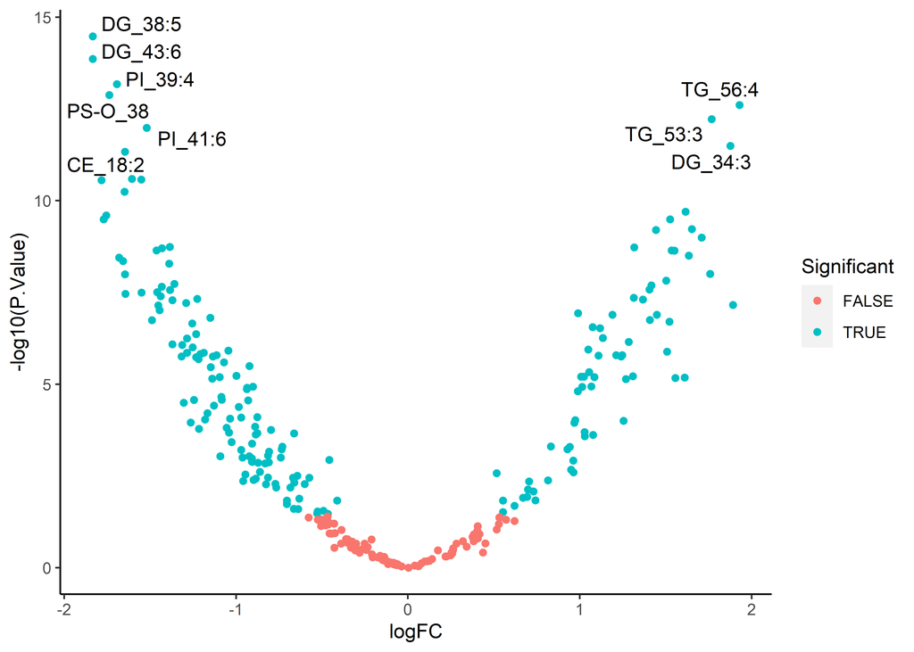

```r
full_results2 %>%
  mutate(Significant = adj.P.Val < p_cutoff, abs(logFC) > fc_cutoff ) %>%
  mutate(Rank = 1:n(), Label = ifelse(Rank < topN,symbols,"")) %>%
  ggplot(aes(x = logFC, y = -log10(P.Value), col=Significant,label=Label)) + geom_point() + geom_text_repel(col="black")+ theme(panel.grid.major = element_blank(), panel.grid.minor = element_blank(),panel.background = element_blank(), axis.line = element_line(colour = "black"))
```

```r
significant_batch2<-full_results2[full_results2$adj.P.Val<p_cutoff,]

head(significant_batch2)
```

```
##   symbols     logFC     AveExpr          t      P.Value    adj.P.Val        B
## 1 DG_38:5 -1.833957 0.008044289 -11.115877 3.355189e-15 9.260321e-13 24.37448
## 2 DG_43:6 -1.834214 0.030313308 -10.684875 1.383043e-14 1.908599e-12 22.96750
## 3 PI_39:4 -1.693211 0.032347451 -10.212007 6.717783e-14 6.180360e-12 21.39697
## 4 PS-O_38 -1.738166 0.021359607 -10.010747 1.327170e-13 9.157471e-12 20.72026
## 5 TG_56:4  1.928321 0.224161721   9.829341 2.461660e-13 1.358836e-11 20.10622
## 6 TG_53:3  1.766265 0.014605727   9.568558 6.022766e-13 2.770473e-11 19.21690
```

```r
dim(significant_batch2)
```

```
## [1] 189   7
```

conduct differential lipid expression for batch 3

```r
design_batch3 <- model.matrix(~0+batch3_clinical_data$NAFLD,ref="steatosis0")

colnames(design_batch3) <- c("Steatosis0","Steatosis1")

lipid_data_limma3<-t(batch3_lipid_scaled)

fit_data3 <- lmFit(lipid_data_limma3, design_batch3)

contrasts3 <- makeContrasts(Steatosis1 - Steatosis0, levels=design_batch3)

fit2_data3 <- contrasts.fit(fit_data3, contrasts3)

fit2_data3<- eBayes(fit2_data3)

full_results3 <- topTable(fit2_data3, number=Inf,adjust = "BH")

full_results3 <- cbind(symbols = rownames(full_results3), full_results3)

rownames(full_results3) <- 1:nrow(full_results3)
```

volcano plot for batch 3

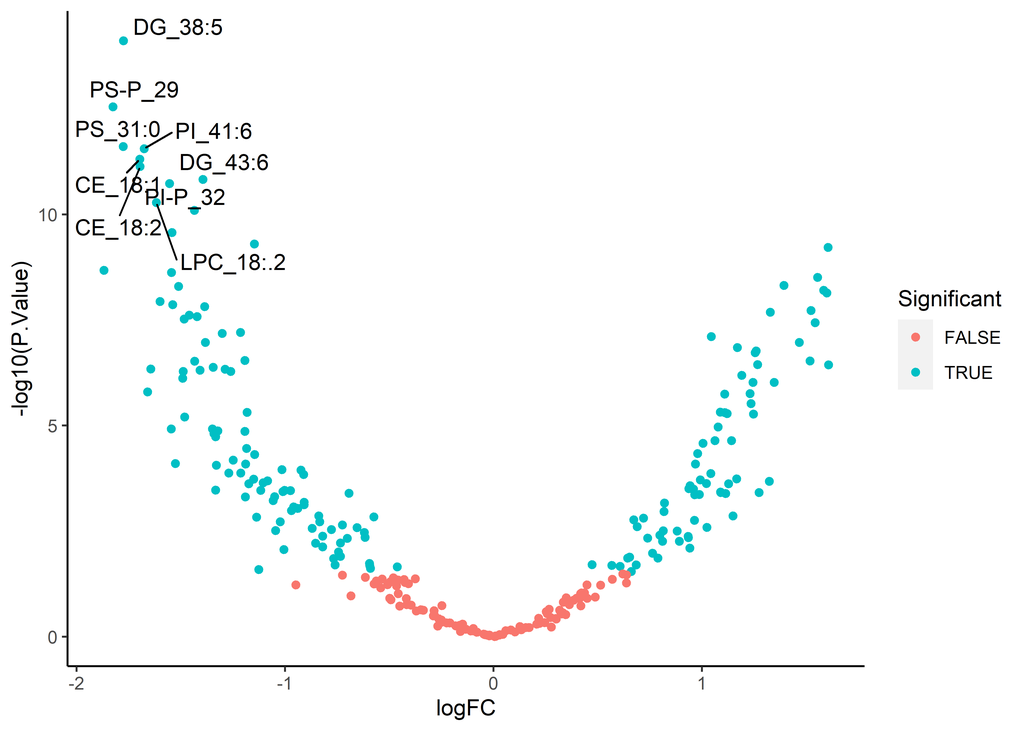

```r
full_results3 %>%
  mutate(Significant = adj.P.Val < p_cutoff, abs(logFC) > fc_cutoff ) %>%
  mutate(Rank = 1:n(), Label = ifelse(Rank < topN,symbols,"")) %>%
  ggplot(aes(x = logFC, y = -log10(P.Value), col=Significant,label=Label)) + geom_point() + geom_text_repel(col="black")+ theme(panel.grid.major = element_blank(), panel.grid.minor = element_blank(),panel.background = element_blank(), axis.line = element_line(colour = "black"))
```

```r
significant_batch3<-full_results2[full_results3$adj.P.Val<p_cutoff,]

head(significant_batch3)
```

```
##   symbols     logFC     AveExpr          t      P.Value    adj.P.Val        B
## 1 DG_38:5 -1.833957 0.008044289 -11.115877 3.355189e-15 9.260321e-13 24.37448
## 2 DG_43:6 -1.834214 0.030313308 -10.684875 1.383043e-14 1.908599e-12 22.96750
## 3 PI_39:4 -1.693211 0.032347451 -10.212007 6.717783e-14 6.180360e-12 21.39697
## 4 PS-O_38 -1.738166 0.021359607 -10.010747 1.327170e-13 9.157471e-12 20.72026
## 5 TG_56:4  1.928321 0.224161721   9.829341 2.461660e-13 1.358836e-11 20.10622
## 6 TG_53:3  1.766265 0.014605727   9.568558 6.022766e-13 2.770473e-11 19.21690
```

```r
dim(significant_batch3)
```

```
## [1] 171   7
```

conduct differential lipid expression for batch 4.

```r
design_batch4 <- model.matrix(~0+batch4_clinical_data$NAFLD,ref="steatosis0")

colnames(design_batch4) <- c("Steatosis0","Steatosis1")

lipid_data_limma4<-t(batch4_lipid_scaled)

fit_data4 <- lmFit(lipid_data_limma4, design_batch4)

contrasts4 <- makeContrasts(Steatosis1 - Steatosis0, levels=design_batch4)

fit2_data4 <- contrasts.fit(fit_data4, contrasts4)

fit2_data4<- eBayes(fit2_data4)

full_results4 <- topTable(fit2_data4, number=Inf,adjust = "BH")

full_results4 <- cbind(symbols = rownames(full_results4), full_results4)

rownames(full_results4) <- 1:nrow(full_results4)
```

volcano plot for batch 4

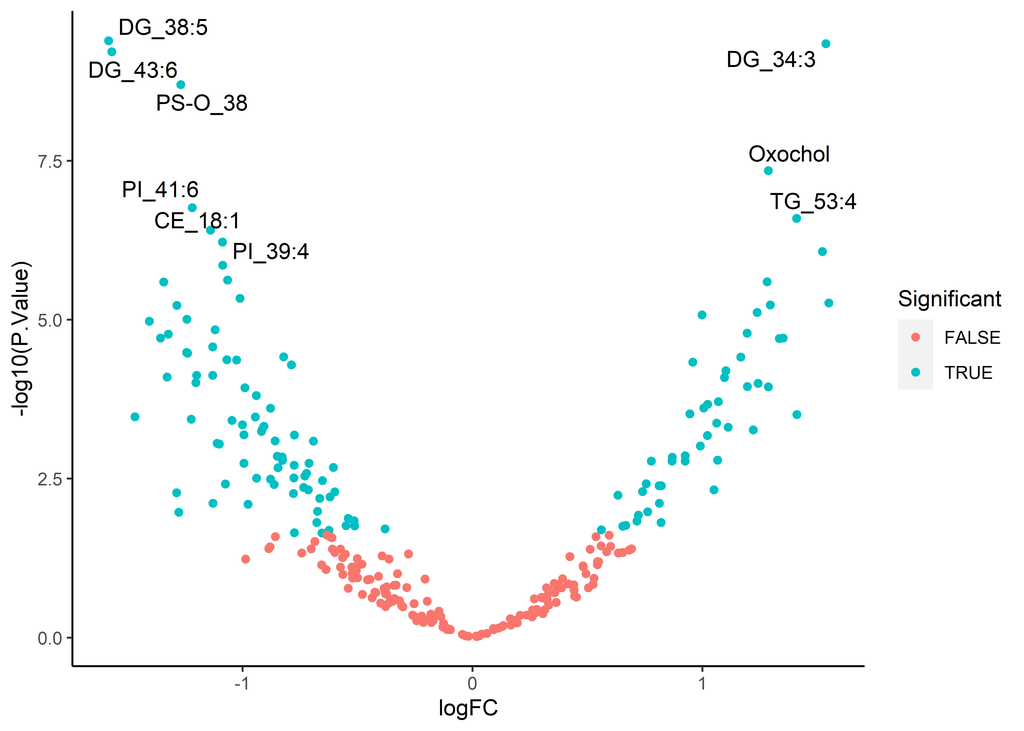

```r
full_results4 %>%
  mutate(Significant = adj.P.Val < p_cutoff, abs(logFC) > fc_cutoff ) %>%
  mutate(Rank = 1:n(), Label = ifelse(Rank < topN,symbols,"")) %>%
  ggplot(aes(x = logFC, y = -log10(P.Value), col=Significant,label=Label)) + geom_point() + geom_text_repel(col="black")+ theme(panel.grid.major = element_blank(), panel.grid.minor = element_blank(),panel.background = element_blank(), axis.line = element_line(colour = "black"))
```

```r
significant_batch4<-full_results4[full_results4$adj.P.Val<p_cutoff,]

head(significant_batch4)
```

```
##   symbols     logFC     AveExpr         t      P.Value    adj.P.Val         B
## 1 DG_38:5 -1.583231 -0.22742195 -7.799571 4.108759e-10 5.608425e-08 12.923874
## 2 DG_34:3  1.536189  0.47264808  7.771243 4.539084e-10 5.608425e-08 12.826047
## 3 DG_43:6 -1.569167 -0.22818895 -7.687448 6.096114e-10 5.608425e-08 12.536394
## 4 PS-O_38 -1.269659 -0.29150250 -7.349281 2.012102e-09 1.388351e-07 11.363847
## 5 Oxochol  1.285460 -0.05608858  6.472756 4.516807e-08 2.493277e-06  8.312214
## 6 PI_41:6 -1.219338 -0.22827882 -6.095570 1.720613e-07 7.914820e-06  7.003015
```

```r
dim(significant_batch4)
```

```
## [1] 129   7
```

Conduct differential lipid expression for batch 5

```r
design_batch5 <- model.matrix(~0+batch5_clinical_data$NAFLD,ref="steatosis0")

colnames(design_batch5) <- c("Steatosis0","Steatosis1")

lipid_data_limma5<-t(batch5_lipid_scaled)

fit_data5 <- lmFit(lipid_data_limma5, design_batch5)

contrasts5 <- makeContrasts(Steatosis1 - Steatosis0, levels=design_batch5)

fit2_data5 <- contrasts.fit(fit_data5, contrasts5)

fit2_data5<- eBayes(fit2_data5)

full_results5 <- topTable(fit2_data5, number=Inf,adjust = "BH")

full_results5 <- cbind(symbols = rownames(full_results5), full_results5)

rownames(full_results5) <- 1:nrow(full_results5)
```

volcano plot for batch 5

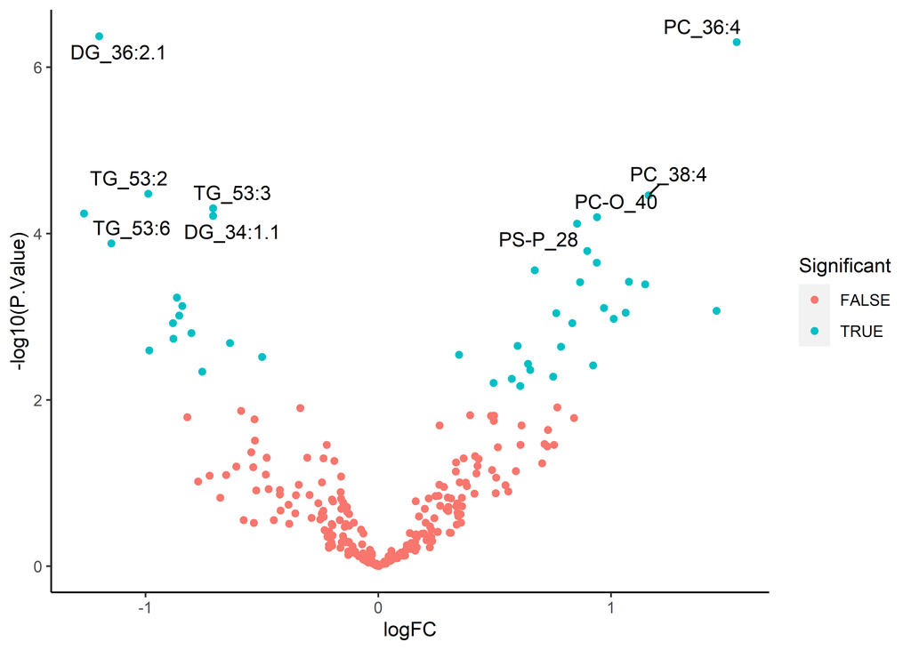

```r
full_results5 %>%
  mutate(Significant = adj.P.Val < p_cutoff, abs(logFC) > fc_cutoff ) %>%
  mutate(Rank = 1:n(), Label = ifelse(Rank < topN,symbols,"")) %>%
  ggplot(aes(x = logFC, y = -log10(P.Value), col=Significant,label=Label)) + geom_point() + geom_text_repel(col="black")+ theme(panel.grid.major = element_blank(), panel.grid.minor = element_blank(),panel.background = element_blank(), axis.line = element_line(colour = "black"))
```

```r
significant_batch5<-full_results5[full_results5$adj.P.Val<p_cutoff,]

head(significant_batch5)
```

```
##     symbols      logFC     AveExpr         t      P.Value    adj.P.Val        B
## 1 DG_36:2.1 -1.1993450  0.49101262 -5.958626 4.239642e-07 6.882647e-05 6.304671
## 2   PC_36:4  1.5397202  0.08691141  5.910031 4.987425e-07 6.882647e-05 6.147818
## 3   TG_53:2 -0.9889126  0.87228183 -4.635981 3.318158e-05 2.184353e-03 2.109665
## 4   PC_38:4  1.1610951 -0.12761206  4.623782 3.450870e-05 2.184353e-03 2.072151
## 5   TG_53:3 -0.7102970  0.86506896 -4.510687 4.957409e-05 2.184353e-03 1.725896
## 6   TG_53:6 -1.2651848  0.69742118 -4.465661 5.722572e-05 2.184353e-03 1.588845
```

```r
dim(significant_batch5)
```

```
## [1] 42  7
```

Conduct different lipid expression for batch 6

```r
design_batch6 <- model.matrix(~0+batch6_clinical_data$NAFLD,ref="steatosis0")

colnames(design_batch6) <- c("Steatosis0","Steatosis1")

lipid_data_limma6<-t(batch6_lipid_scaled)

fit_data6 <- lmFit(lipid_data_limma6, design_batch6)

contrasts6 <- makeContrasts(Steatosis1 - Steatosis0, levels=design_batch6)

fit2_data6 <- contrasts.fit(fit_data6, contrasts6)

fit2_data6 <- eBayes(fit2_data6)

full_results6 <- topTable(fit2_data6, number=Inf,adjust = "BH")

full_results6 <- cbind(symbols = rownames(full_results6), full_results6)

rownames(full_results6) <- 1:nrow(full_results6)
```

volcano plot for batch 6

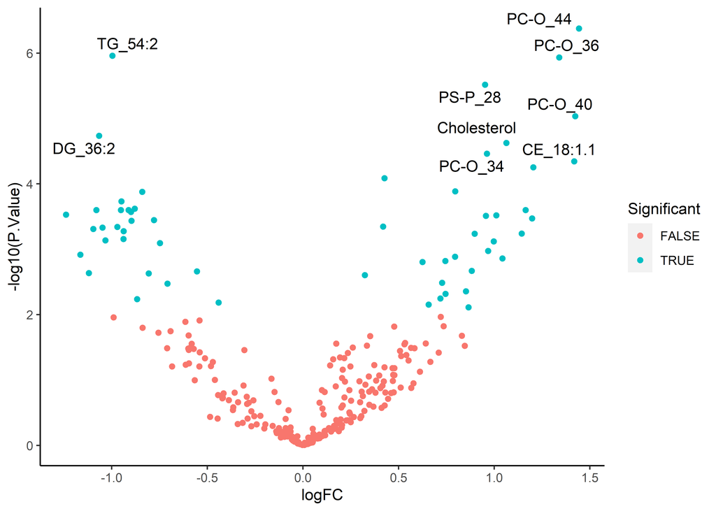

```r
full_results6 %>%
  mutate(Significant = adj.P.Val < p_cutoff, abs(logFC) > fc_cutoff ) %>%
  mutate(Rank = 1:n(), Label = ifelse(Rank < topN,symbols,"")) %>%
  ggplot(aes(x = logFC, y = -log10(P.Value), col=Significant,label=Label)) + geom_point() + geom_text_repel(col="black")+ theme(panel.grid.major = element_blank(), panel.grid.minor = element_blank(),panel.background = element_blank(), axis.line = element_line(colour = "black"))
```

```r
significant_batch6<-full_results6[full_results6$adj.P.Val<p_cutoff,]

head(significant_batch6)
```

```
##   symbols      logFC     AveExpr         t      P.Value    adj.P.Val        B
## 1 PC-O_44  1.4429320  0.10057341  5.973130 4.210383e-07 0.0001069434 6.326011
## 2 TG_54:2 -0.9965229  0.21923572 -5.685326 1.095100e-06 0.0001069434 5.405205
## 3 PC-O_36  1.3393702 -0.06098412  5.667329 1.162428e-06 0.0001069434 5.347761
## 4 PS-P_28  0.9521793 -0.14752453  5.376447 3.041048e-06 0.0002098323 4.422556
## 5 PC-O_40  1.4239131  0.06407383  5.038354 9.218303e-06 0.0005088503 3.357679
## 6 DG_36:2 -1.0665274  0.37025704 -4.825684 1.839361e-05 0.0008461062 2.695810
```

```r
dim(significant_batch6)
```

```
## [1] 57  7
```

Find the intersecting significant lipids among the 6 batches

```r
lipids_batch1<-significant_batch1$symbols

lipids_batch2<-significant_batch2$symbols

lipids_batch3<-significant_batch3$symbols

lipids_batch4<-significant_batch4$symbols

lipids_batch5<-significant_batch5$symbols

lipids_batch6<-significant_batch6$symbols



intersected_lipids<-Reduce(intersect,list(lipids_batch1,lipids_batch2,lipids_batch3,lipids_batch4,lipids_batch5,lipids_batch6))

print(intersected_lipids)
```

```
##  [1] "TG_53:3"     "DG_34:1"     "TG_52:3"     "TG_52:2.1"   "TG_53:2"
##  [6] "TG_53:7"     "TG_54:2"     "DG_36:2"     "TG_53:6"     "CE_16:0.1"
## [11] "Cholesterol"
```

conduct different expression of lipid only with the intersected lipids

```r
common_lipid_scaled<-lipid_scaled[,colnames(lipid_scaled) %in% intersected_lipids]

design_final <- model.matrix(~0+clinical_data$NAFLD,ref="steatosis0")

colnames(design_final) <- c("Steatosis1","Steatosis0")

lipid_data_limma_final<-t(common_lipid_scaled)

fit_data_final <- lmFit(lipid_data_limma_final, design_final)

contrasts_final <- makeContrasts(Steatosis1 - Steatosis0, levels=design_final)

fit2_data_final <- contrasts.fit(fit_data_final, contrasts_final)

fit2_data_final<- eBayes(fit2_data_final)

full_results_final <- topTable(fit2_data_final, number=Inf,adjust = "BH")

full_results_final <- cbind(symbols = rownames(full_results_final), full_results_final)

rownames(full_results_final) <- 1:nrow(full_results_final)

print(full_results_final)
```

```
##        symbols      logFC       AveExpr         t      P.Value    adj.P.Val
## 1      TG_53:3 -1.0295330  3.430077e-17 -4.531666 6.307155e-06 0.0000693787
## 2    CE_16:0.1  0.9155465  2.225613e-16  4.029935 5.853538e-05 0.0003219446
## 3      TG_52:3 -0.8818559 -5.731354e-17 -3.881640 1.081696e-04 0.0003904006
## 4      TG_53:7 -0.8665732  5.344425e-17 -3.814371 1.419638e-04 0.0003904006
## 5      DG_36:2 -0.8525358  4.763723e-17 -3.752583 1.815657e-04 0.0003994444
## 6    TG_52:2.1 -0.8391009  7.714598e-17 -3.693447 2.290206e-04 0.0004198711
## 7      TG_53:2 -0.7702227  3.874216e-17 -3.390267 7.160239e-04 0.0011251804
## 8      DG_34:1 -0.7479340 -1.896877e-16 -3.292160 1.016891e-03 0.0013982253
## 9      TG_54:2 -0.7253484 -4.478293e-17 -3.192745 1.437954e-03 0.0017574991
## 10 Cholesterol  0.6866663  3.254021e-16  3.022480 2.548805e-03 0.0028036859
## 11     TG_53:6 -0.4913213  1.675669e-17 -2.162635 3.072386e-02 0.0307238648
##             B
## 1   3.5407333
## 2   1.4405388
## 3   0.8669213
## 4   0.6138069
## 5   0.3852174
## 6   0.1699332
## 7  -0.8800780
## 8  -1.2006081
## 9  -1.5158089
## 10 -2.0331984
## 11 -4.2129728
```

visualize

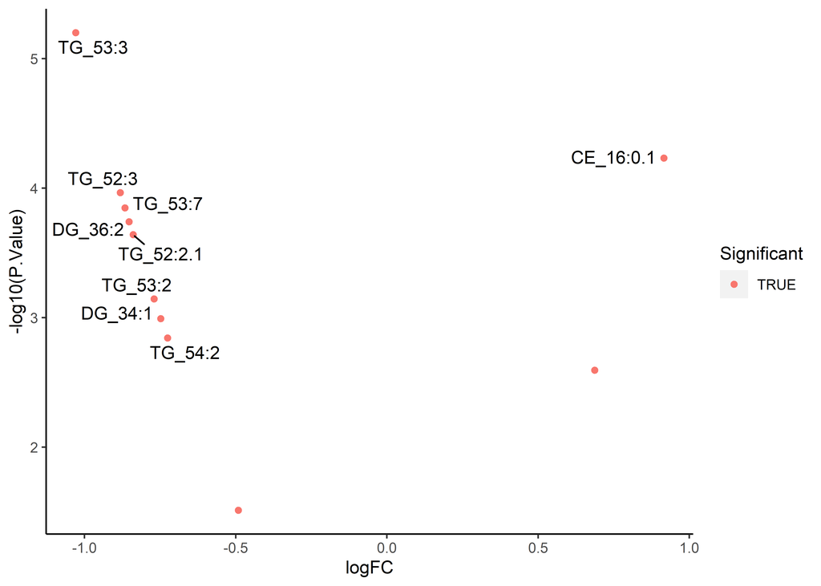

```r
full_results_final %>%
  mutate(Significant = adj.P.Val < p_cutoff, abs(logFC) > fc_cutoff ) %>%
  mutate(Rank = 1:n(), Label = ifelse(Rank < topN,symbols,"")) %>%
  ggplot(aes(x = logFC, y = -log10(P.Value), col=Significant,label=Label)) + geom_point() + geom_text_repel(col="black")+ theme(panel.grid.major = element_blank(), panel.grid.minor = element_blank(),panel.background = element_blank(), axis.line = element_line(colour = "black"))
```

```r
significant_final<-full_results_final[full_results_final$adj.P.Val<p_cutoff,]

head(significant_final)
```

```
##     symbols      logFC       AveExpr         t      P.Value    adj.P.Val
## 1   TG_53:3 -1.0295330  3.430077e-17 -4.531666 6.307155e-06 0.0000693787
## 2 CE_16:0.1  0.9155465  2.225613e-16  4.029935 5.853538e-05 0.0003219446
## 3   TG_52:3 -0.8818559 -5.731354e-17 -3.881640 1.081696e-04 0.0003904006
## 4   TG_53:7 -0.8665732  5.344425e-17 -3.814371 1.419638e-04 0.0003904006
## 5   DG_36:2 -0.8525358  4.763723e-17 -3.752583 1.815657e-04 0.0003994444
## 6 TG_52:2.1 -0.8391009  7.714598e-17 -3.693447 2.290206e-04 0.0004198711
##           B
## 1 3.5407333
## 2 1.4405388
## 3 0.8669213
## 4 0.6138069
## 5 0.3852174
## 6 0.1699332
```

```r
dim(significant_final)
```

```
## [1] 11  7
```

lets observe the -log10(P.value) of the significant lipids with a plot

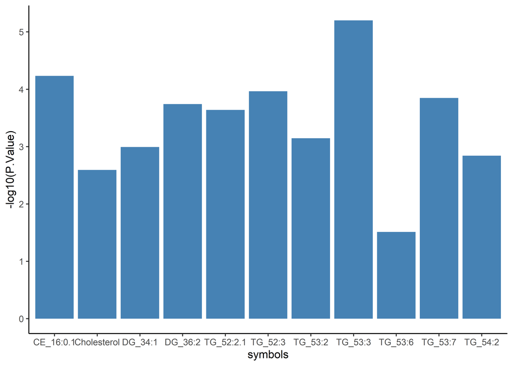

```r
graph<-ggplot(data=significant_final, aes(x=symbols, y=-log10(P.Value))) +
  geom_bar(stat="identity", fill="steelblue")+theme(panel.grid.major = element_blank(), panel.grid.minor = element_blank(),panel.background = element_blank(), axis.line = element_line(colour = "black"))

graph
```

observe the lipids logFC of the lipid

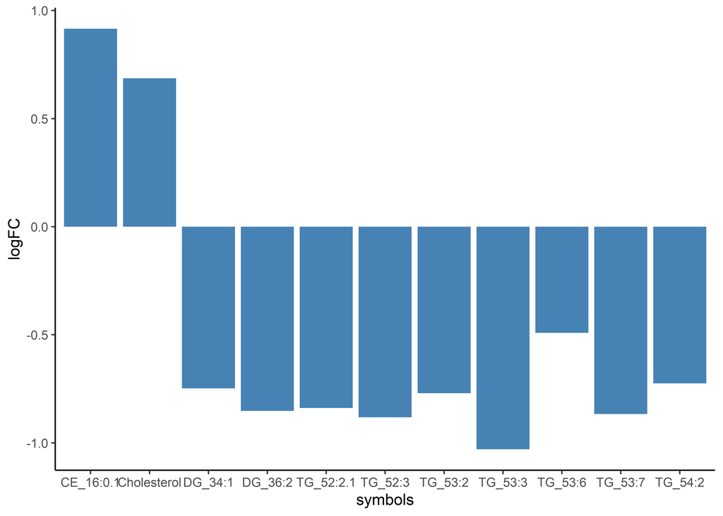

```r
graph_FC<-ggplot(data=significant_final, aes(x=symbols, y=logFC)) +
  geom_bar(stat="identity", fill="steelblue")+
  theme(panel.grid.major = element_blank(), panel.grid.minor = element_blank(),
        panel.background = element_blank(), axis.line = element_line(colour = "black"))

graph_FC
```